# #backOfaFagPacket: Retrofit or bust?

Ben Anderson

Last run at: 2020-11-10 18:05:19

> This fridayFagPacket was first published as a [blog](https://dataknut.wordpress.com/2020/10/16/retrofit-or-bust/)

# 1 fridayFagPackets

Numbers that could have been done on the back of one and should probably come with a similar health warning…

> Find out [more](https://dataknut.github.io/fridayFagPackets/).

It seems like we can’t snooze for a second without HM Govt announcing another ‘build back better’ initiative. The sentiment behind these is totally to be applauded: invest public £ in job (and skill) creating schemes which help fix our [energy inefficient homes](https://www.theccc.org.uk/publication/uk-housing-fit-for-the-future/) thereby reducing energy demand (and carbon emissions), increasing thermal comfort and reducing poor health outcomes. Win4.

Schemes seen to date include:

- £2 billion [Green Homes Grant](https://www.gov.uk/guidance/apply-for-the-green-homes-grant-scheme): make energy improvements to your home insulation & low carbon heat vouchers
- £50 million [Social Housing Decarbonisation Fund Demonstrator](https://www.gov.uk/government/publications/social-housing-decarbonisation-fund-demonstrator) (SHDF Demonstrator) in prep for the future
- £3.8 billion [Social Housing Decarbonisation Fund](https://www.housing.org.uk/news-and-blogs/news/chancellors-statement-and-affordable-homes-programme/)

These sound like big numbers.

But how much is it really going to cost to bring our homes up to standard, assuming we can even agree what standard is required for our [greenhouse gas emissions reduction objectives](https://www.theccc.org.uk/publication/uk-housing-fit-for-the-future/)?

# 2 Ballparks

If we want a very ‘[back of a fag packet](https://www.collinsdictionary.com/submission/11813/back+of+a+fag+packet)‘ estimate for England we can start with the excellent research provided by the English [Housing Survey 2018](https://www.gov.uk/government/statistics/english-housing-survey-2018-energy-report) reports.

# 3 How big is the problem?

Pretty big.

[Table AT1.5](https://assets.publishing.service.gov.uk/government/uploads/system/uploads/attachment_data/file/898341/Energy_Chapter_1_Figures_and_Annex_Tables.xlsx) gives us the number of dwellings and the average SAP-modelled annual energy cost by EPC band. Note that modelled energy cost includes space heating, cooling and hot water but not appliances.

A quick calculation (see Table 1 below) shows that:

- we spend an estimated £22.5 bn a year on (this kind of) energy in English dwellings;
- **we currently have about 15 million dwellings rated D-G that need ‘fixing’ if band C is our ‘standard to be met’**;
- and possibly another 8 million rated C which might also need a fix.

To get even the 15 million D-G over the line by 2050 means fixing 10,000 or more a week for the next 30 years. Go us. What about the costs?

Very helpfully [Table AT3.4](https://assets.publishing.service.gov.uk/government/uploads/system/uploads/attachment_data/file/898343/Energy_Chapter_3_Figures_and_Annex_Tables.xlsx) in Chapter 3 of the same report provides some remarkably over-precise average ‘upgrade‘ costs for bands A-E (£13,347) and F&G (£26.891). The table also gives us equally precise ‘post-improvement notional total energy current cost (£/yr)‘ of £415 (band A-E) and £515 (bands F & G).

If we:

- assume that band A/B dwellings don’t need and don’t get a fix (possibly untrue) and… ( the retrofit costs and annual post-improvement energy costs are constant within C-E and F & G as above (almost certainly untrue but hey, it’s an average…)

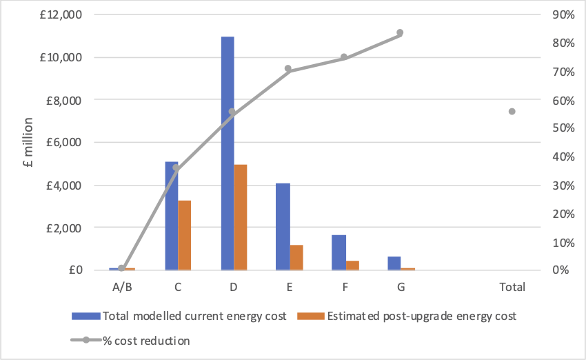

Estimated current energy costs, post-improvement costs and % reduction for English dwellings

> Figure 1: Estimated current energy costs, post-improvement costs and % reduction for English dwellings (EHS 2018, own calculations, see Table below for detail)

Remember the £3.8bn [Social Housing Decarbonisation Fund](https://www.housing.org.uk/news-and-blogs/news/chancellors-statement-and-affordable-homes-programme/)? Well according to the EHS 2018 social housing is already leading the way with 56% of them in bands A-C compared to under 30% of owner-occupied. As a result if we ignore the A-Cs then we ‘only’ need to invest £24bn in social housing retrofits for the 1.79m D-G dwellings (see Table 3 below). If we include the A-Cs (the published tables don’t give a A/B/C breakdown) it’s a £54bn investment. On these numbers, £3.8bn a year for 10 years might see this sector home…

Privately rented dwellings are in the same ball park – £46bn or £68bn depending if we include A-C. But the big problem is the 15.2m (63%) owner occupied homes of whom 70% are in band D-G. If we ignore the A-Cs someone needs to find £154bn for this sector and £214bn if we include them. Given emerging evidence on [why owners don’t improve their dwellings](https://onlinelibrary.wiley.com/doi/full/10.1111/1753-6405.12895) this is going to be the big one.

# 4 In sum

Is all this enough to hit our carbon targets? Getting all dwellings up to A/B standard is one approach and it should mean we have a lot less heat energy to decarbonise. Scarily for some, £12bn would also be quite a big chunk out of the retail energy sector’s annual turnover.

To be sure, £332 bn sounds a lot but remember that the annual English NHS budget is [~£130 bn and rising](https://fullfact.org/health/spending-english-nhs/) in a ‘normal’ year. In contrast, according to our fag packet we ‘just’ need to invest £11bn a year (at current prices) for 30 years in dwelling improvements. This co-incidentally also helps to [reduce the NHS budget](https://jech.bmj.com/content/63/4/271.short?casa_token=QjmF0S0mRK4AAAAA:PH24tAPvDC7teVFPiOSwxksd2ZjSD91XTLV4rpZCl5DefSUWO_oPmfVlDa-uZjhKCdsRyaUEXxk) through improved health co-benefits. Ideally of course we’d want a front-loaded investment to ‘build back better’, help us deliver quickly on our [COP commitments](https://www.gov.uk/government/topical-events/cop26) and [regain at least some moral high ground](https://www.theccc.org.uk/publication/reducing-uk-emissions-2020-progress-report-to-parliament/).

# 5 But are we barking up the wrong tree?

However for reasons that are excellently explained in a recent [PassivHaus Trust report](https://www.passivhaustrust.org.uk/guidance_detail.php?gId=44), focusing on EPC bands might be a red herring. This is because ‘high’ EPC bands can be met by installing on-site low carbon generation (e.g. PV) without having to reduce energy inputs and the EPC rating uses energy-input carbon intensity values that are rapidly out of date, especially for electricity. As a result as ‘the carbon emissions associated with expensive electricity continue to reduce, this makes the EPC rating system increasingly inaccurate and means that a highly rated dwelling could potentially produce a very high rate of emissions‘ (p11).

The Trust instead recommends a focus on space conditioning energy intensity (kWh/m2) as a primary metric. This would mean deciding what kWh/m2 standards we want to hit and devising policy settings and support mechanisms to enable the industry to deliver them at speed and scale.

Intriguingly this is exactly what N[ew Zealand’s Ministry of Business, Innovation and Employment (MBIE)](https://www.mbie.govt.nz/dmsdocument/11793-transforming-operational-efficiency) is currently consulting on with respect to new build dwellings as part of their Building for Climate Change: Transforming operational efficiency and reducing whole-of-life embodied carbon programme. Watch this space.

# 6 Detailed tables

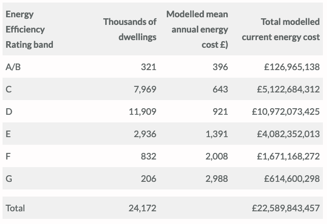

Table 1

> Table 1: Adapted from EHS 2018 Report: Annex Table 1.5: Average modelled energy costs, by dwelling characteristics, 2018 (with additional total column, over-precision retained for hilarity)

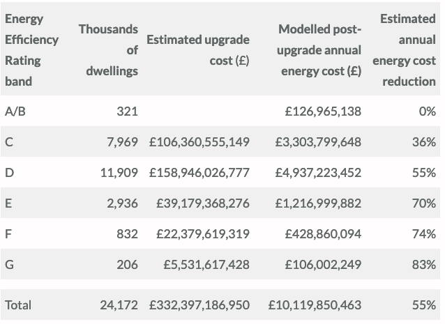

Table 2

> Table 2: Estimated retrofit costs and % energy savings (over-precision retained for hilarity)

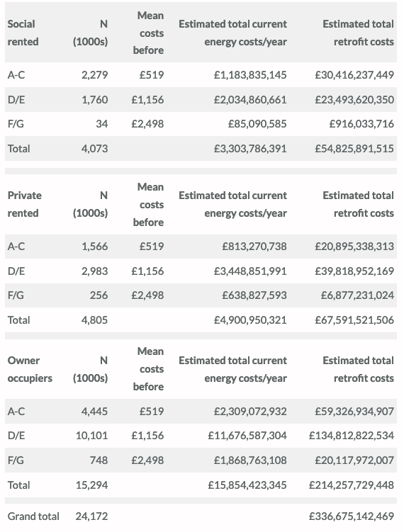

Table 3

> Table 3: Current estimated energy costs and estimated retrofit costs by tenure (EHS 2018 Report Table AT1.2, own calculations as for Table 2, over-precision retained for hilarity))

# 7 R packages used

- rmarkdown (Allaire et al. 2018)
- bookdown (Xie 2016a)
- knitr (Xie 2016b)

# References

Allaire, JJ, Yihui Xie, Jonathan McPherson, Javier Luraschi, Kevin Ushey, Aron Atkins, Hadley Wickham, Joe Cheng, and Winston Chang. 2018. *Rmarkdown: Dynamic Documents for R*. https://CRAN.R-project.org/package=rmarkdown.

Xie, Yihui. 2016a. *Bookdown: Authoring Books and Technical Documents with R Markdown*. Boca Raton, Florida: Chapman; Hall/CRC. https://github.com/rstudio/bookdown.

———. 2016b. *Knitr: A General-Purpose Package for Dynamic Report Generation in R*. https://CRAN.R-project.org/package=knitr.